# Assignment 2

Milo

03/10/2021

```r
library(dplyr)
```

```r
library(ggplot2)
library(ggpubr)
library(Hmisc)
library(PerformanceAnalytics)
library(corrplot)
library(tidyr)
library(tidyverse)
library(datasets)
library(scales)
#Get your current working directory in R using **getwd ()** function
#getwd()
dir=getwd()
```

```r
#Set your working  directory in R using **setwd ()** function
#setwd ()
setwd(dir)
```

#Task 1 Missing values

```r
dat <- read.csv("Movie.csv", header=TRUE)
names(dat)
```

```
##  [1] "Color"                     "Director"
##  [3] "Reviews"                   "Duration"
##  [5] "Director_facebook_likes"   "Actor_3_facebook_likes"
##  [7] "Actor_2_name"              "Actor_1_facebook_likes"
##  [9] "Gross"                     "Genre"
## [11] "Actor_1_name"              "Title"
## [13] "Votes"                     "Cast_total_facebook_likes"
## [15] "Actor_3_name"              "Facenumber_in_poster"
## [17] "Plot_keywords"             "Movie_imdb_link"
## [19] "Language"                  "Content_rating"
## [21] "Budget"                    "Year"
## [23] "Actor_2_facebook_likes"    "Imdb_score"
## [25] "Aspect_ratio"              "Movie_facebook_likes"
```

```r
str(dat)
```

```
## 'data.frame':    3891 obs. of  26 variables:
##  $ Color                    : chr  "Color" "Color" "Color" "Color" ...
##  $ Director                 : chr  "James Cameron" "Gore Verbinski" "Sam Mendes" "Christopher Nolan" ...
##  $ Reviews                  : int  723 302 602 813 462 392 324 635 375 673 ...
##  $ Duration                 : int  178 169 148 164 132 156 100 141 153 183 ...
##  $ Director_facebook_likes  : int  0 563 0 22000 475 0 15 0 282 0 ...
##  $ Actor_3_facebook_likes   : int  855 1000 161 23000 530 4000 284 19000 10000 2000 ...
##  $ Actor_2_name             : chr  "Joel David Moore" "Orlando Bloom" "Rory Kinnear" "Christian Bale" ...
##  $ Actor_1_facebook_likes   : int  1000 40000 11000 27000 640 24000 799 26000 25000 15000 ...
##  $ Gross                    : int  760505847 309404152 200074175 448130642 73058679 336530303 200807262 458991599 301956980 330249062 ...
##  $ Genre                    : chr  "Action" "Action" "Action" "Action" ...
##  $ Actor_1_name             : chr  "CCH Pounder" "Johnny Depp" "Christoph Waltz" "Tom Hardy" ...
##  $ Title                    : chr  "Avatara" "Pirates of the Caribbean: At World's Enda" "Spectrea" "The Dark Knight Risesa" ...
##  $ Votes                    : int  886204 471220 275868 1144337 212204 383056 294810 462669 321795 371639 ...
##  $ Cast_total_facebook_likes: int  2791 46563 11554 95000 2277 39000 1651 66000 46282 21000 ...
##  $ Actor_3_name             : chr  "Wes Studi" "Jack Davenport" "Stephanie Sigman" "Joseph Gordon-Levitt" ...
##  $ Facenumber_in_poster     : int  0 0 1 0 1 0 1 4 3 0 ...
##  $ Plot_keywords            : chr  "avatar|future|marine|native|paraplegic" "goddess|marriage ceremony|marriage proposal|pirate|singapore" "bomb|espionage|sequel|spy|terrorist" "deception|imprisonment|lawlessness|police officer|terrorist plot" ...
##  $ Movie_imdb_link          : chr  "http://www.imdb.com/title/tt0499549/?ref_=fn_tt_tt_1" "http://www.imdb.com/title/tt0449088/?ref_=fn_tt_tt_1" "http://www.imdb.com/title/tt2379713/?ref_=fn_tt_tt_1" "http://www.imdb.com/title/tt1345836/?ref_=fn_tt_tt_1" ...
##  $ Language                 : chr  "English" "English" "English" "English" ...
##  $ Content_rating           : chr  "PG-13" "" "PG-13" "PG-13" ...
##  $ Budget                   : num  2.37e+08 3.00e+08 2.45e+08 2.50e+08 2.64e+08 ...
##  $ Year                     : int  2009 2007 2015 2012 2012 2007 2010 2015 2009 2016 ...
##  $ Actor_2_facebook_likes   : int  936 5000 393 23000 632 11000 553 21000 11000 4000 ...
##  $ Imdb_score               : num  7.9 7.1 6.8 8.5 6.6 6.2 7.8 7.5 7.5 6.9 ...
##  $ Aspect_ratio             : num  1.78 2.35 2.35 2.35 2.35 2.35 1.85 2.35 2.35 2.35 ...
##  $ Movie_facebook_likes     : int  33000 0 85000 164000 24000 0 29000 118000 10000 197000 ...
```

```r
sum(is.na(dat)) #Total amount of NAs before replacing blank cells with NAs
```

```
## [1] 101
```

```r
#replace blank with NA
dat[dat == ""] <- NA
```

```r
sum(is.na(dat)) #Total amount of NAs after replacing blank cells with NAs
```

```
## [1] 226
```

Number of NA in each column

```r
colnames(dat)[colSums(is.na(dat)) > 0] #Names of columns that have NA
```

```
##  [1] "Color"                  "Reviews"                "Duration"
##  [4] "Actor_3_facebook_likes" "Actor_2_name"           "Actor_1_facebook_likes"
##  [7] "Actor_1_name"           "Actor_3_name"           "Facenumber_in_poster"
## [10] "Plot_keywords"          "Content_rating"         "Actor_2_facebook_likes"
## [13] "Aspect_ratio"
```

```r
col_NA <- colSums(is.na(dat)) #The amount of NA each column has
col_NA
```

```
##                     Color                  Director                   Reviews
##                         2                         0                         1
##                  Duration   Director_facebook_likes    Actor_3_facebook_likes
##                         1                         0                        10
##              Actor_2_name    Actor_1_facebook_likes                     Gross
##                         5                         3                         0
##                     Genre              Actor_1_name                     Title
##                         0                         3                         0
##                     Votes Cast_total_facebook_likes              Actor_3_name
##                         0                         0                        10
##      Facenumber_in_poster             Plot_keywords           Movie_imdb_link
##                         6                        31                         0
##                  Language            Content_rating                    Budget
##                         0                        74                         0
##                      Year    Actor_2_facebook_likes                Imdb_score
##                         0                         5                         0
##              Aspect_ratio      Movie_facebook_likes
##                        75                         0
```

```r
class(col_NA)
```

```
## [1] "numeric"
```

Look at how many NAs for columns that have more than 0 NA and calculate the % of NA per variable.

```r
for (e in 1:ncol(dat)){
  if (colSums(is.na(dat[,e, drop = FALSE]))>0) {print(paste("Column ", colnames(dat)[e], " has ", colSums(is.na(dat[,e, drop = FALSE])), " NA ", " which is only ","(", colSums(is.na(dat[,e, drop = FALSE])),"/3891)*100 = ", round((colSums(is.na(dat[,e, drop = FALSE]))/3891)*100, digits = 2), "% of the variable.", sep = ""))
    }
}
```

```
## [1] "Column Color has 2 NA  which is only (2/3891)*100 = 0.05% of the variable."
## [1] "Column Reviews has 1 NA  which is only (1/3891)*100 = 0.03% of the variable."
## [1] "Column Duration has 1 NA  which is only (1/3891)*100 = 0.03% of the variable."
## [1] "Column Actor_3_facebook_likes has 10 NA  which is only (10/3891)*100 = 0.26% of the variable."
## [1] "Column Actor_2_name has 5 NA  which is only (5/3891)*100 = 0.13% of the variable."
## [1] "Column Actor_1_facebook_likes has 3 NA  which is only (3/3891)*100 = 0.08% of the variable."
## [1] "Column Actor_1_name has 3 NA  which is only (3/3891)*100 = 0.08% of the variable."
## [1] "Column Actor_3_name has 10 NA  which is only (10/3891)*100 = 0.26% of the variable."
## [1] "Column Facenumber_in_poster has 6 NA  which is only (6/3891)*100 = 0.15% of the variable."
## [1] "Column Plot_keywords has 31 NA  which is only (31/3891)*100 = 0.8% of the variable."
## [1] "Column Content_rating has 74 NA  which is only (74/3891)*100 = 1.9% of the variable."
## [1] "Column Actor_2_facebook_likes has 5 NA  which is only (5/3891)*100 = 0.13% of the variable."
## [1] "Column Aspect_ratio has 75 NA  which is only (75/3891)*100 = 1.93% of the variable."
```

The amount of NAs in the columns that have NAs is minuscule. Except for column Aspect_ratio and Content_rating that has significantly higher NAs than other columns. However, at 1.9% NAs, it is still very small. Therefore no columns should be deleted due to the amount of NAs.

Look at how many NAs for rows that have more than 0 NA.

```r
a <-0
for (e in 1:nrow(dat)){
  if (rowSums(is.na(dat[e,]))>0) {print(paste("observation", e, "has", rowSums(is.na(dat[e,])), "NA"))
    a <- a + 1
    }
}
```

```
## [1] "observation 2 has 1 NA"
## [1] "observation 18 has 1 NA"
## [1] "observation 53 has 1 NA"
## [1] "observation 87 has 1 NA"
## [1] "observation 96 has 1 NA"
## [1] "observation 125 has 1 NA"
## [1] "observation 153 has 1 NA"
## [1] "observation 164 has 1 NA"
## [1] "observation 198 has 1 NA"
## [1] "observation 237 has 1 NA"
## [1] "observation 240 has 1 NA"
## [1] "observation 265 has 1 NA"
## [1] "observation 272 has 1 NA"
## [1] "observation 306 has 1 NA"
## [1] "observation 360 has 1 NA"
```

[output cut: 142 more lines]

```r
print(paste(a,"out of 3891 obversations has NA", ". Which is only", round((a/3891)*100,digits = 2), "% of the data"))
```

```
## [1] "157 out of 3891 obversations has NA . Which is only 4.03 % of the data"
```

There are 26 columns/variables. The amount of NAs for observations that have NAs is very small (ranging from 1-8 NAs). Since there are 3891 observations in this dataset, we can safely remove all variables that has NAs which is only about 4% of the data set without introducing bias.

```r
dat.cleaned <- na.omit(dat)
any(is.na(dat.cleaned))
```

```
## [1] FALSE
```

```r
dim(dat.cleaned)
```

```
## [1] 3734   26
```

After removing 157 observations with NAs, there are now 3734 obs left which is still a large amount of dataset for unbias correlation exploration.

#Task 2 Exploration: #Based on the Dataset, calculate “Profit” and determine the relationship between “Profit” and other variables (e.g. IMDB score). Hint: Profit = Gross – Budget. Use line plot or scatter plot to find the relationship.

There are no NAs in variable gross nor budget so therefore we can create a column profit as usually.

```r
dat2 <- dat.cleaned
dat2$Profit <- dat2$Gross - dat2$Budget
head(dat2)
```

```
##   Color          Director Reviews Duration Director_facebook_likes
## 1 Color     James Cameron     723      178                       0
## 3 Color        Sam Mendes     602      148                       0
## 4 Color Christopher Nolan     813      164                   22000
## 5 Color    Andrew Stanton     462      132                     475
## 6 Color         Sam Raimi     392      156                       0
## 7 Color      Nathan Greno     324      100                      15
##   Actor_3_facebook_likes     Actor_2_name Actor_1_facebook_likes     Gross
## 1                    855 Joel David Moore                   1000 760505847
## 3                    161     Rory Kinnear                  11000 200074175
## 4                  23000   Christian Bale                  27000 448130642
## 5                    530  Samantha Morton                    640  73058679
## 6                   4000     James Franco                  24000 336530303
## 7                    284     Donna Murphy                    799 200807262
##       Genre    Actor_1_name                  Title   Votes
```

[output cut: 41 more lines]

We will explore the relationship between profit and other comparable variables such as: Movie_facebook_likes, Aspect_ratio, Imdb_score, Actor_2_facebook_likes, Year, Budget, Content_rating, Facenumber_in_poster, Cast_total_facebook_likes, Votes, Genre, Gross, Actor_1_facebook_likes, Actor_3_facebook_likes, Director_facebook_likes, Duration, Reviews, Color.

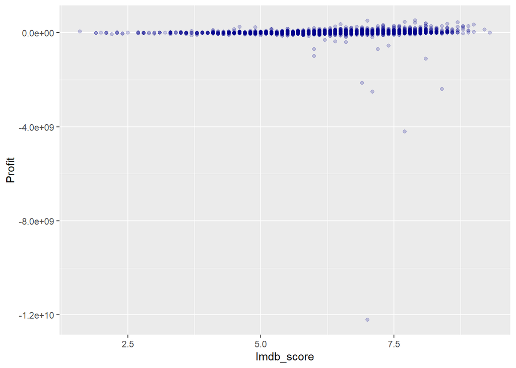

```r
#Profit vs Imdb_score
ggplot(data = dat2, mapping = aes(y = Profit, x = Imdb_score)) + geom_point(color = 'darkblue', alpha=1/5)
```

Since there are a few outliners of movies that made losses, it has made the scatter plot scale spread out and hard to visualise the correlation. For example, according to the plot, there was a movie that lost 12 billions dollars. It is questionable if this movie really made a loss of 12 billions dollars or was it a data error. Therefore, a new dataframe will be created to only take entries for only movies that made more than -200 millions dollars.

```r
dat_profit <- dat2[dat2$Profit >= -2e8,]
head(dat_profit)
```

```
##   Color          Director Reviews Duration Director_facebook_likes
## 1 Color     James Cameron     723      178                       0
## 3 Color        Sam Mendes     602      148                       0
## 4 Color Christopher Nolan     813      164                   22000
## 5 Color    Andrew Stanton     462      132                     475
## 6 Color         Sam Raimi     392      156                       0
## 7 Color      Nathan Greno     324      100                      15
##   Actor_3_facebook_likes     Actor_2_name Actor_1_facebook_likes     Gross
## 1                    855 Joel David Moore                   1000 760505847
## 3                    161     Rory Kinnear                  11000 200074175
## 4                  23000   Christian Bale                  27000 448130642
## 5                    530  Samantha Morton                    640  73058679
## 6                   4000     James Franco                  24000 336530303
## 7                    284     Donna Murphy                    799 200807262
##       Genre    Actor_1_name                  Title   Votes
```

[output cut: 41 more lines]

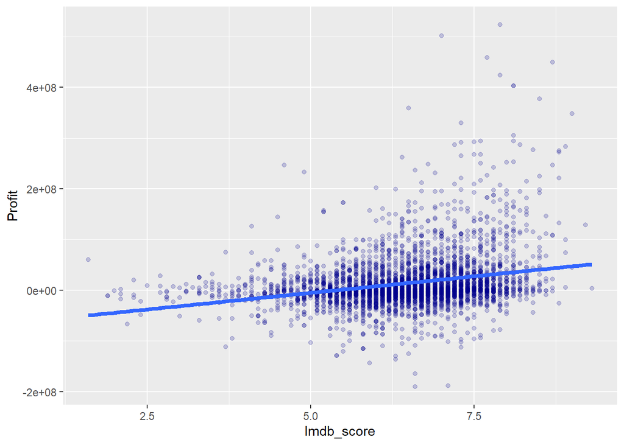

```r
ggplot(data = dat_profit, mapping = aes(y = Profit, x = Imdb_score)) + geom_point(color = 'darkblue', alpha =1/5) +geom_smooth(se=FALSE,
              method = "lm",
              formula = y~poly(x,1),
              size = 1.5)
```

There is a positive correlation between Imdb_score and profit. As Imdb_score increases, profit is predicted to increase also.

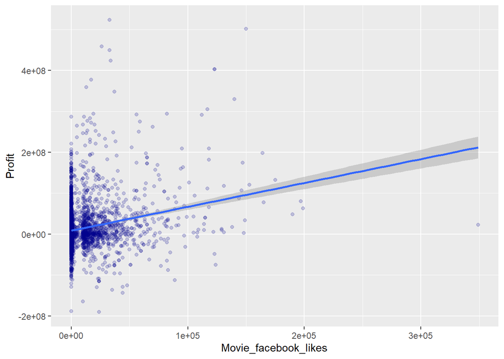

```r
ggplot(data = dat_profit, mapping = aes(y = Profit, x = Movie_facebook_likes)) + geom_point(color = 'darkblue', alpha =1/5)+geom_smooth(method = "lm")
```

There is a positive correlation between Movie_facebook_likes and profit. As Movie_facebook_likes increases, profit is predicted to increase also. However, there is 1 outliner where Movie_facebook_likes is really high but profit is low. If it wasn’t for this outliner, the regression line may even show a higher positive correlation.

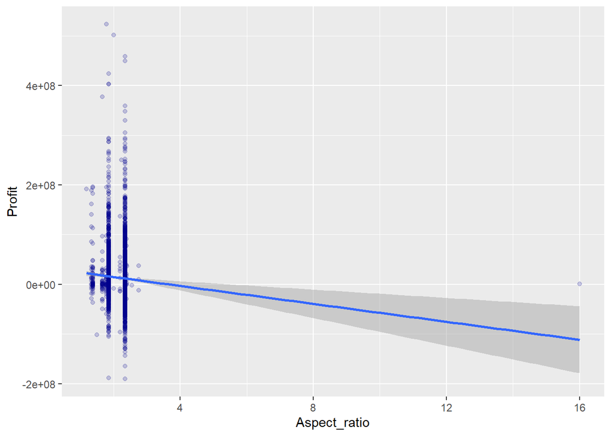

```r
ggplot(data = dat_profit, mapping = aes(y = Profit, x = Aspect_ratio)) + geom_point(color = 'darkblue', alpha=1/5)+geom_smooth(method = "lm")
```

According to the regression line, there seems to be a slight negative correlation between profit and Aspect_ratio. However, there is an outliner of Aspect_ratio being 16 with low profit, this could have skewed the regression line. Perhaps if it wasn’t for this outliner, the regression line could have been horizontal, hence no relationship between Profit and Aspect_ratio.

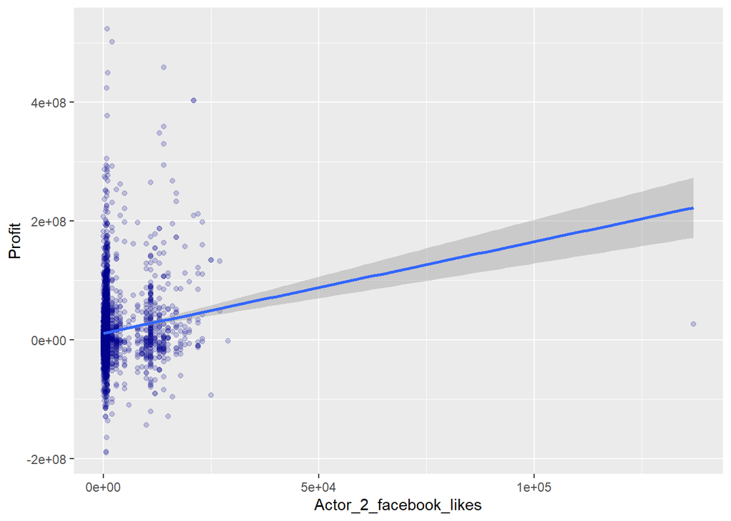

```r
ggplot(data = dat_profit, mapping = aes(y = Profit, x = Actor_2_facebook_likes)) + geom_point(color = 'darkblue', alpha =1/5) +geom_smooth(method = "lm")
```

There is a positive correlation between Actor_2_facebook_likes and Profit. As Actor_2_facebook_likes increases, profit seems to also increase. There is an outliner of really high Actor_2_facebook_likes but low profit. Perhaps if it wasn’t for this outliner, the regression line would have been steeper, hence, higher positive correlation.

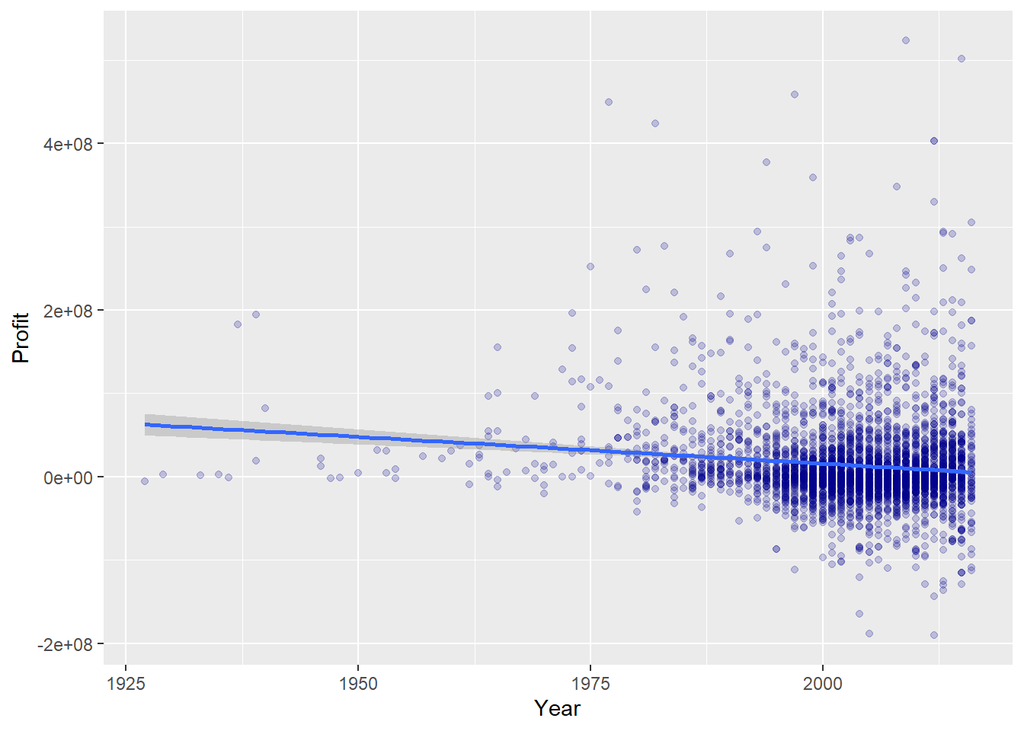

```r
ggplot(data = dat_profit, mapping = aes(x = Year, y = Profit)) + geom_point(color = 'darkblue', alpha =1/5) +geom_smooth(method = "lm")
```

Interestingly and unexpectedly, as Year increases, Profit seems to slightly decrease. There is a negative correlation between Year and Profit. There are many new movies that make really high profit but there are also many that made losses.

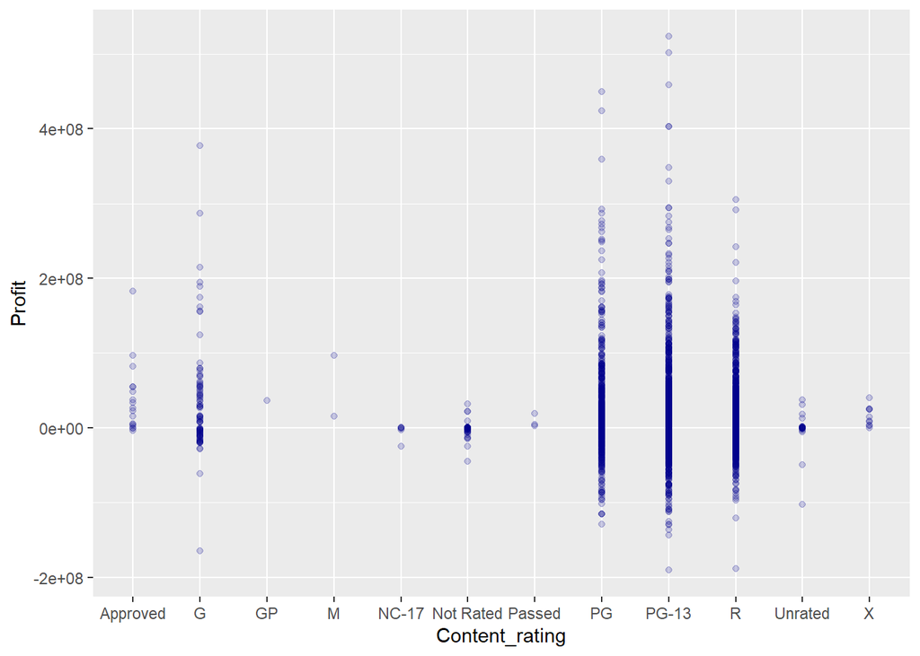

```r
ggplot(data = dat_profit, mapping = aes(y = Profit, x = Content_rating)) + geom_point(color = 'darkblue', alpha =1/5) +geom_smooth(method = "lm")
```

In terms of Content_rating, PG-13 and PG have movies from losses and to high profit and some outliners with really high profit. R and G are spread out from losses to medium and high profit. Not Rated seem to make more losses than profit. Almost all aprroved rating seem to make profit but they are as high PG, PG-13, G, and R. The rest of the categories seem to not have as many movies.

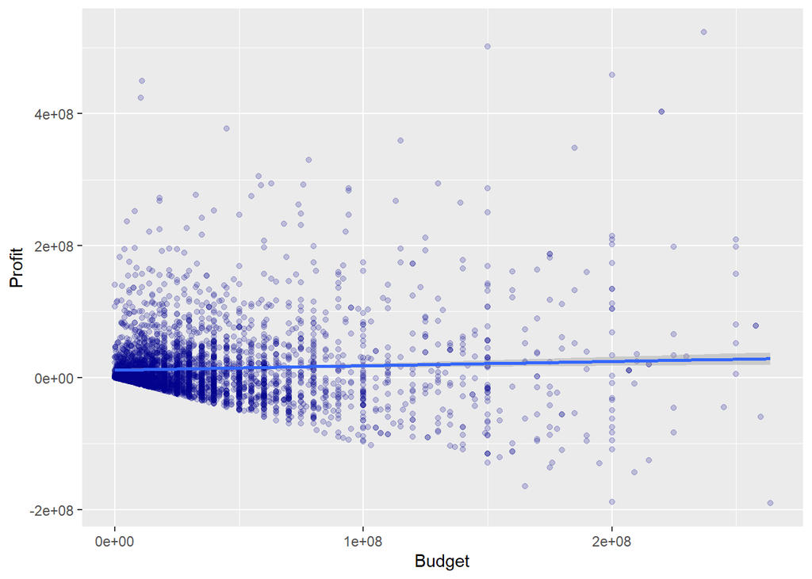

```r
ggplot(data = dat_profit, mapping = aes(y = Profit, x = Budget)) + geom_point(color = 'darkblue', alpha=1/5) +geom_smooth(method = "lm")
```

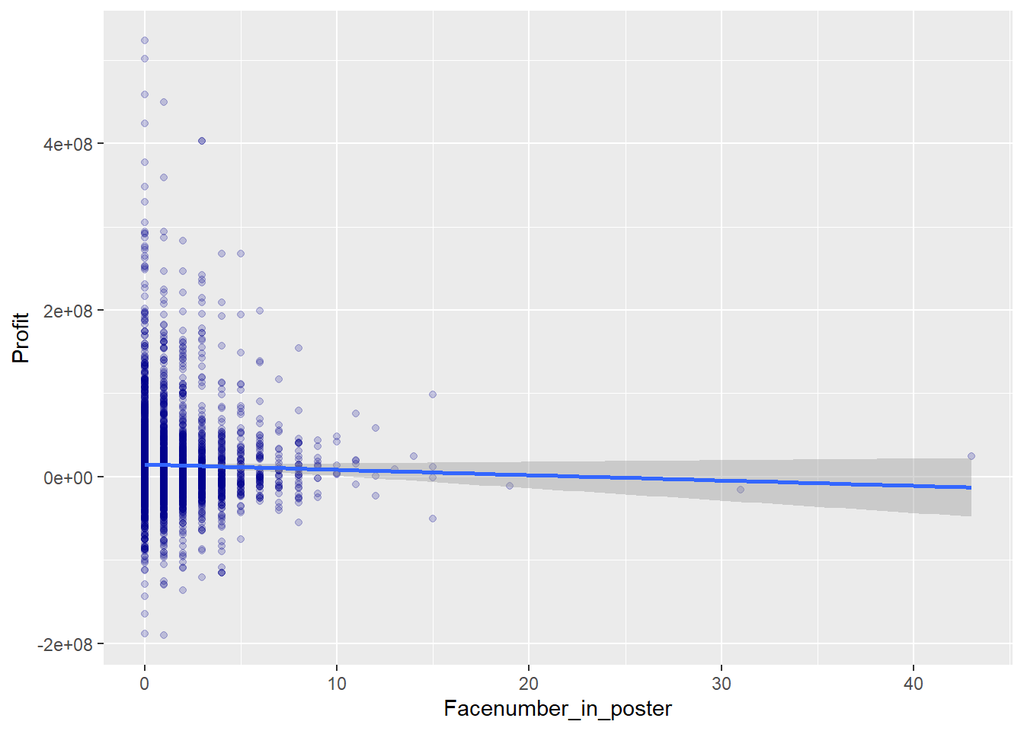

```r
ggplot(data = dat_profit, mapping = aes(y = Profit, x = Facenumber_in_poster)) + geom_point(color = 'darkblue', alpha =1/5) +geom_smooth(method = "lm")
```

There is a slight negative correlation between Facenumber_in_poster and Profit. There are also 2 outliners where Facenumber_in_poster are high but Profit is low which could have skewed the regression line a little bit. If it wasn’t for these 2 outliners, may we find that the regression line could be a little bit flatter which could mean that there is no correlation between Facenumber_in_poster and Profit.

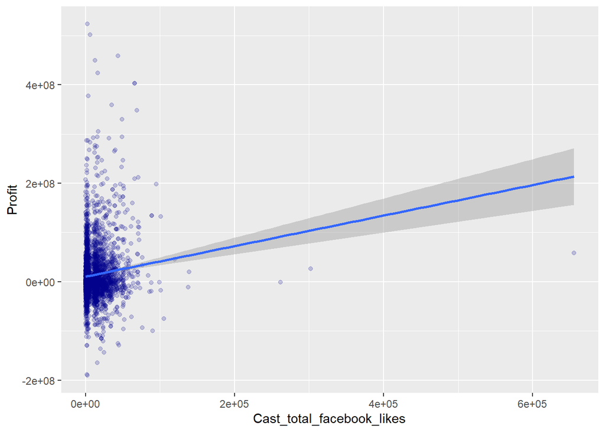

```r
ggplot(data = dat_profit, mapping = aes(y = Profit, x = Cast_total_facebook_likes)) + geom_point(color = 'darkblue', alpha=1/5) +geom_smooth(method = "lm")
```

There is a positive correlation between Cast_total_facebook_likes and Profit. It is predicted that as Cast_total_facebook_likes increases, profit increases. If it wasn’t for the outliner in the far right, the positive correlation may even be stronger.

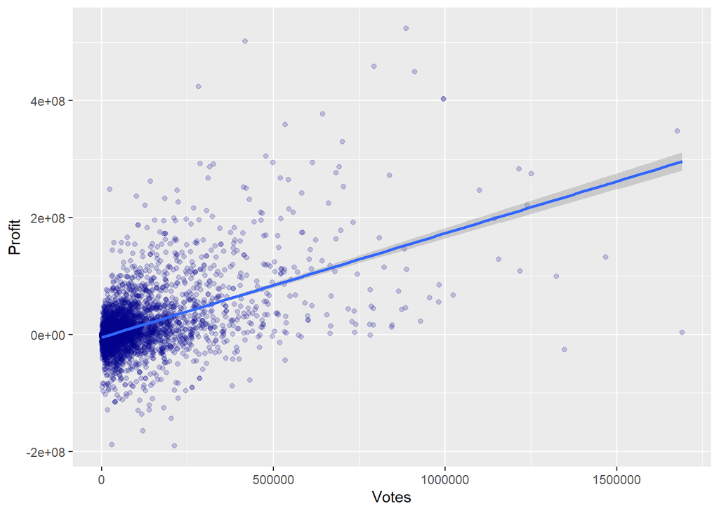

```r
ggplot(data = dat_profit, mapping = aes(y = Profit, x = Votes)) + geom_point(color = 'darkblue', alpha=1/5) +geom_smooth(method = "lm")
```

There is a positive correlation between Votes and Profit. It is predicted that as Votes increases, profit increases.

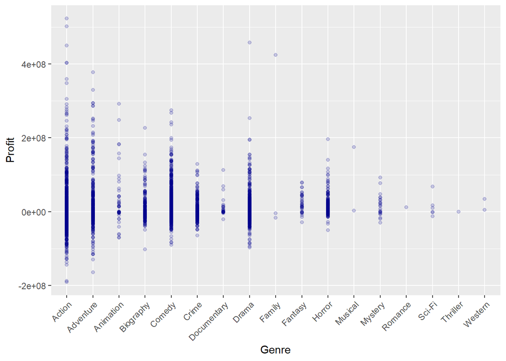

```r
ggplot(data = dat_profit, mapping = aes(y = Profit, x = Genre)) + geom_point(color = 'darkblue', alpha =1/5) +geom_smooth(method = "lm") + theme(axis.text.x = element_text(angle = 45, hjust=1))
```

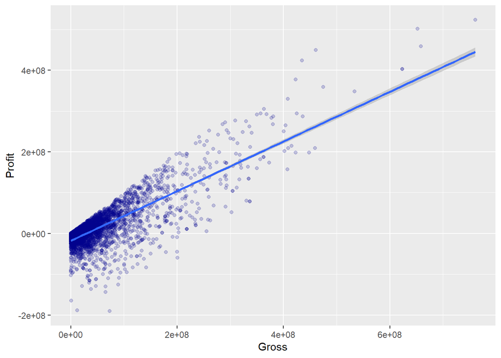

```r
ggplot(data = dat_profit, mapping = aes(y = Profit, x = Gross)) + geom_point(color = 'darkblue', alpha =1/5) +geom_smooth(method = "lm")
```

As expected, the more money you make, the higher the profit. This shows strong positive correlation correlation.

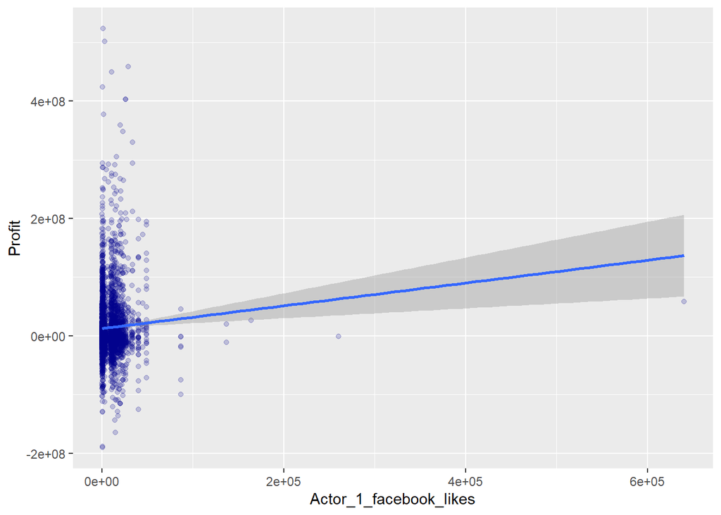

```r
ggplot(data = dat_profit, mapping = aes(y = Profit, x = Actor_1_facebook_likes)) + geom_point(color = 'darkblue', alpha =1/5) +geom_smooth(method = "lm")
```

There is a very slight positive correlation between Actor_1_facebook_likes and Profit. As Actor_1_facebook_likes increases, Profit is expected to slightly increase. If it wasn’t for the far right outliner, the regression line might even be steeper.

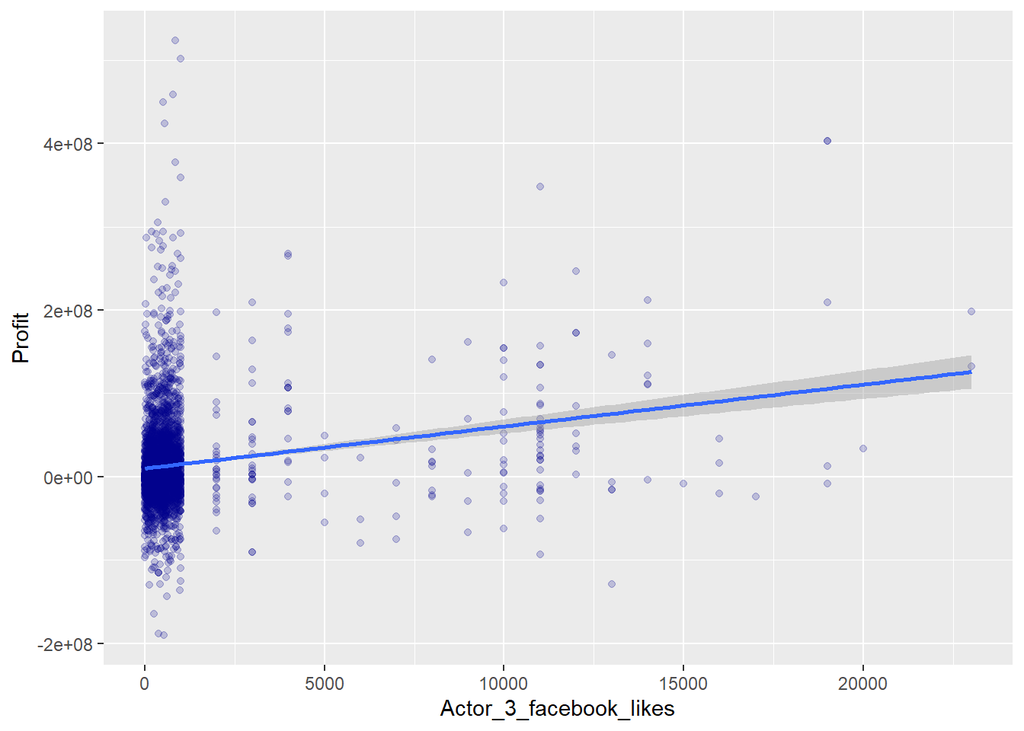

```r
ggplot(data = dat_profit, mapping = aes(y = Profit, x = Actor_3_facebook_likes)) + geom_point(color = 'darkblue', alpha = 1/5) +geom_smooth(method = "lm")
```

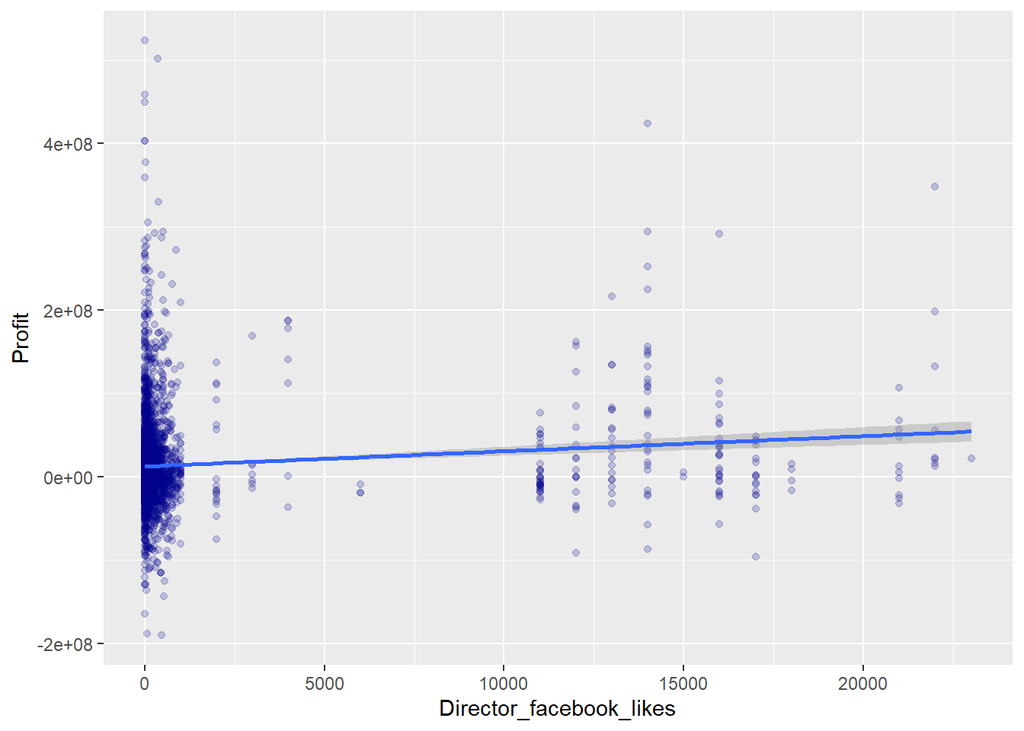

```r
ggplot(data = dat_profit, mapping = aes(y = Profit, x = Director_facebook_likes)) + geom_point(color = 'darkblue', alpha=1/5) +geom_smooth(method = "lm")
```

There is a very low positive correlation between Director_facebook_likes and Profit, many directors with no to little fb likes.

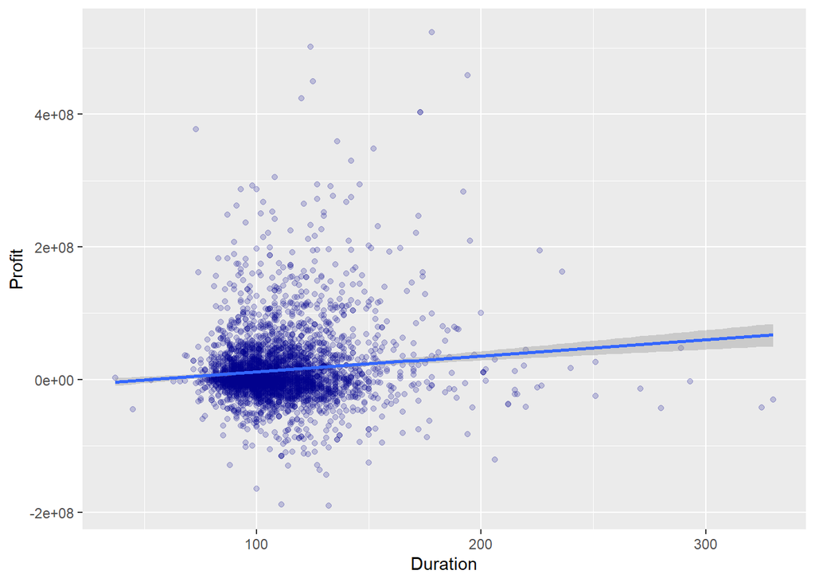

```r
ggplot(data = dat_profit, mapping = aes(y = Profit, x = Duration)) + geom_point(color = 'darkblue', alpha=1/5) +geom_smooth(method = "lm")
```

There is a low positive correlation between Duration and Profit. The majority of movies have duration between 50 mins to 150 mins. The longer the duration of a movie doesn’t mean higher the profit.

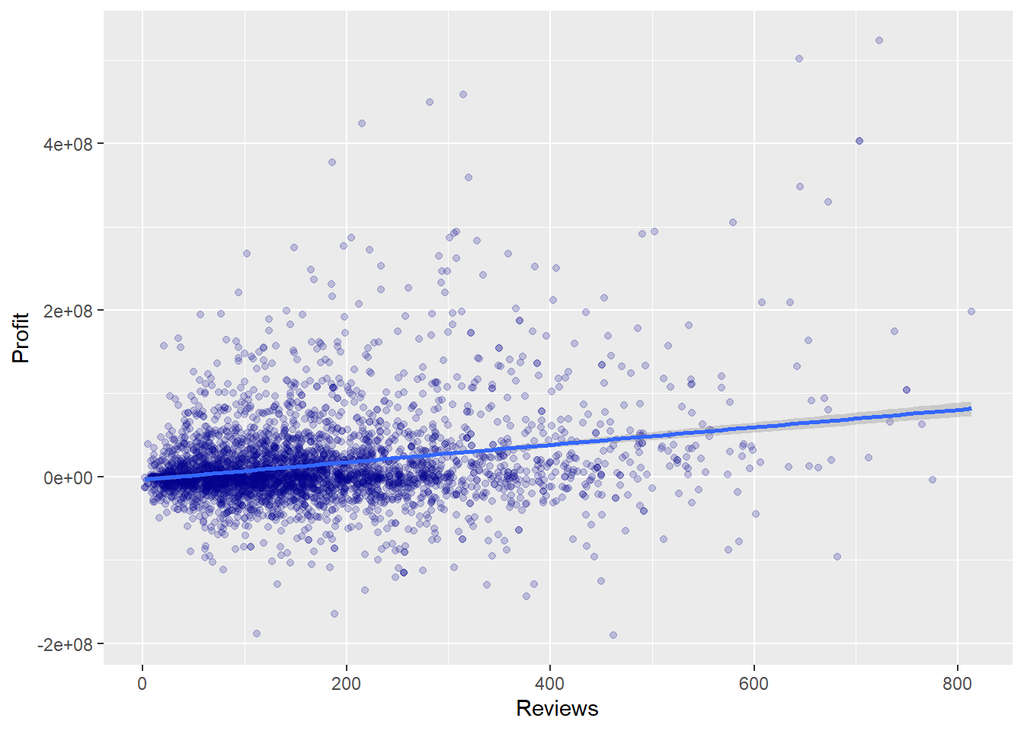

```r
ggplot(data = dat_profit, mapping = aes(y = Profit, x = Reviews)) + geom_point(color = 'darkblue', alpha=1/5) +geom_smooth(method = "lm")
```

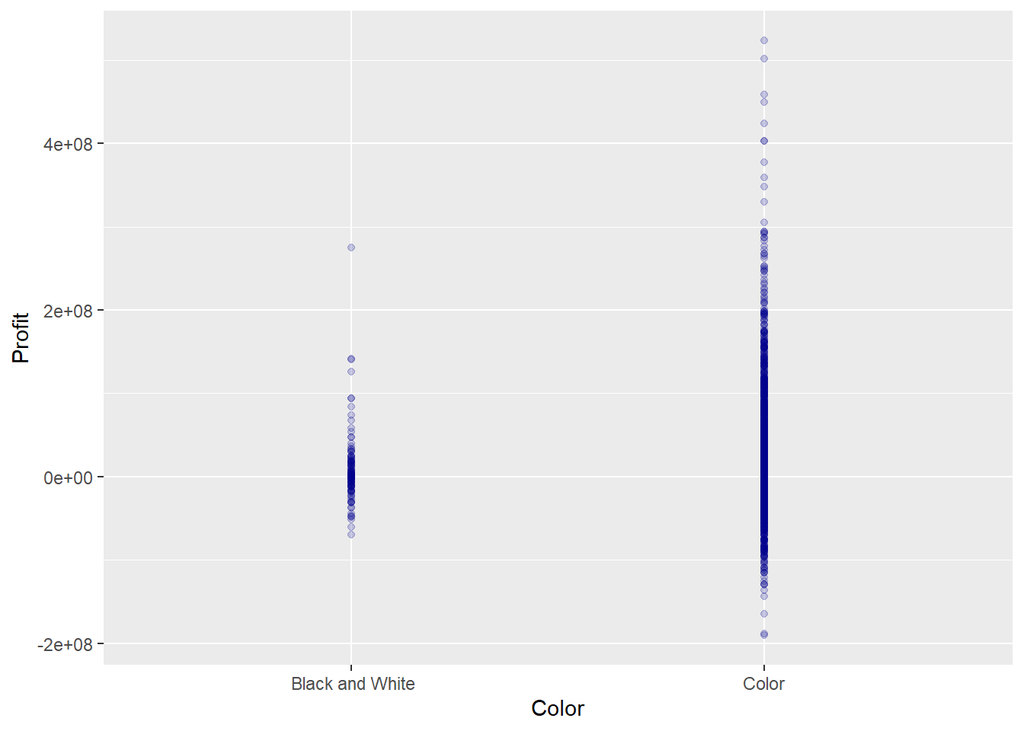

```r
ggplot(data = dat_profit, mapping = aes(y = Profit, x = Color)) + geom_point(color = 'darkblue', alpha=1/5) +geom_smooth(se=FALSE,
              method = "lm",
              formula = y~poly(x,1),
              size = 1.5)
```

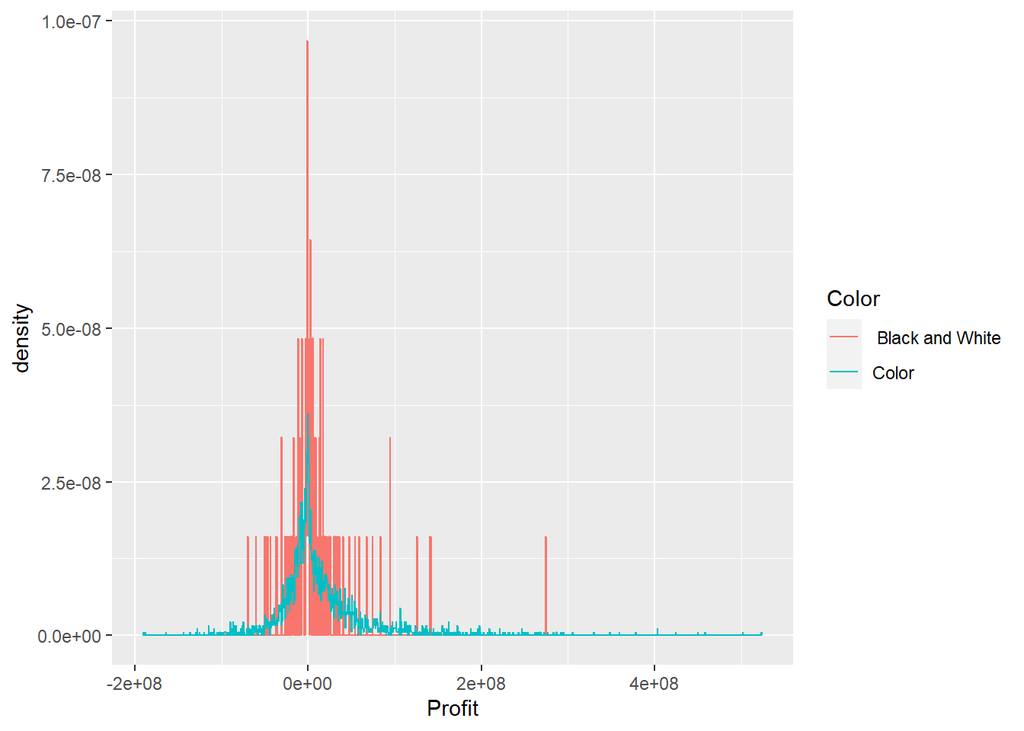

```r
ggplot(data = dat_profit, mapping = aes(x = Profit, y = ..density..)) + geom_freqpoly(mapping = aes(colour = Color), binwidth = 500000)
```

Generally, Colar movies can make a lot more money than Black and White but they can also lose a lot more profit as well. There are more Color movies as supposed to Black and White. In the density plot, it can be seen that a large amount of black and white movies make little to no profit.

#Calculate the correlation between the variable(s) used in the Dataset.

```r
#Select only numeric variables for correlation matrix
dat_num <- dat2 %>% select_if(is.numeric)
dat_cor<- cor(dat_num)
round(dat_cor, 2)
```

```
##                           Reviews Duration Director_facebook_likes
## Reviews                      1.00     0.23                    0.18
## Duration                     0.23     1.00                    0.18
## Director_facebook_likes      0.18     0.18                    1.00
## Actor_3_facebook_likes       0.25     0.13                    0.12
## Actor_1_facebook_likes       0.16     0.08                    0.09
## Gross                        0.46     0.24                    0.14
## Votes                        0.59     0.34                    0.30
## Cast_total_facebook_likes    0.25     0.14                    0.27
## Facenumber_in_poster        -0.03     0.03                   -0.05
## Budget                       0.10     0.07                    0.02
## Year                         0.42    -0.13                   -0.04
## Actor_2_facebook_likes       0.25     0.13                    0.12
## Imdb_score                   0.35     0.37                    0.19
## Aspect_ratio                 0.18     0.15                    0.04
## Movie_facebook_likes         0.70     0.22                    0.16
## Profit                       0.04     0.01                    0.02
##                           Actor_3_facebook_likes Actor_1_facebook_likes Gross
## Reviews                                     0.25                   0.16  0.46
## Duration                                    0.13                   0.08  0.24
## Director_facebook_likes                     0.12                   0.09  0.14
## Actor_3_facebook_likes                      1.00                   0.25  0.30
## Actor_1_facebook_likes                      0.25                   1.00  0.14
## Gross                                       0.30                   0.14  1.00
## Votes                                       0.27                   0.18  0.62
## Cast_total_facebook_likes                   0.45                   0.94  0.23
## Facenumber_in_poster                        0.10                   0.06 -0.03
## Budget                                      0.04                   0.02  0.10
## Year                                        0.12                   0.09  0.05
## Actor_2_facebook_likes                      0.55                   0.39  0.25
## Imdb_score                                  0.06                   0.09  0.22
## Aspect_ratio                                0.05                   0.06  0.06
## Movie_facebook_likes                        0.27                   0.13  0.37
## Profit                                      0.05                   0.03  0.21
##                           Votes Cast_total_facebook_likes Facenumber_in_poster
## Reviews                    0.59                      0.25                -0.03
## Duration                   0.34                      0.14                 0.03
## Director_facebook_likes    0.30                      0.27                -0.05
## Actor_3_facebook_likes     0.27                      0.45                 0.10
## Actor_1_facebook_likes     0.18                      0.94                 0.06
```

[output cut: 30 more lines]

```
## Duration                          0.15                 0.22   0.01
## Director_facebook_likes           0.04                 0.16   0.02
## Actor_3_facebook_likes            0.05                 0.27   0.05
## Actor_1_facebook_likes            0.06                 0.13   0.03
## Gross                             0.06                 0.37   0.21
## Votes                             0.08                 0.52   0.13
## Cast_total_facebook_likes         0.07                 0.21   0.04
## Facenumber_in_poster              0.02                 0.02   0.01
## Budget                            0.02                 0.05  -0.95
## Year                              0.22                 0.31  -0.03
## Actor_2_facebook_likes            0.06                 0.23   0.04
## Imdb_score                        0.03                 0.28   0.04
## Aspect_ratio                      1.00                 0.11  -0.01
## Movie_facebook_likes              0.11                 1.00   0.06
## Profit                           -0.01                 0.06   1.00
```

[figure not shown]

```r
corrplot(dat_cor, method = "pie", type = "upper", tl.pos="l")
```

We will use dat2 to plot for correlations that don’t involve profit as one of the variables. This way we can incldue all observations.

dat_profit will be used for most correlations that have profit as one of the variables because due to outliners, it would easier to visualise when we exclude those that make less than $200 millions. However, dat2 will be used for the correlation of budget and profit and the reason will be explained below.

#Strong correlations

Actor_1_facebook_likes has a strong positive correlation with Cast_total_facebook_likes with coefficient of 0.94.

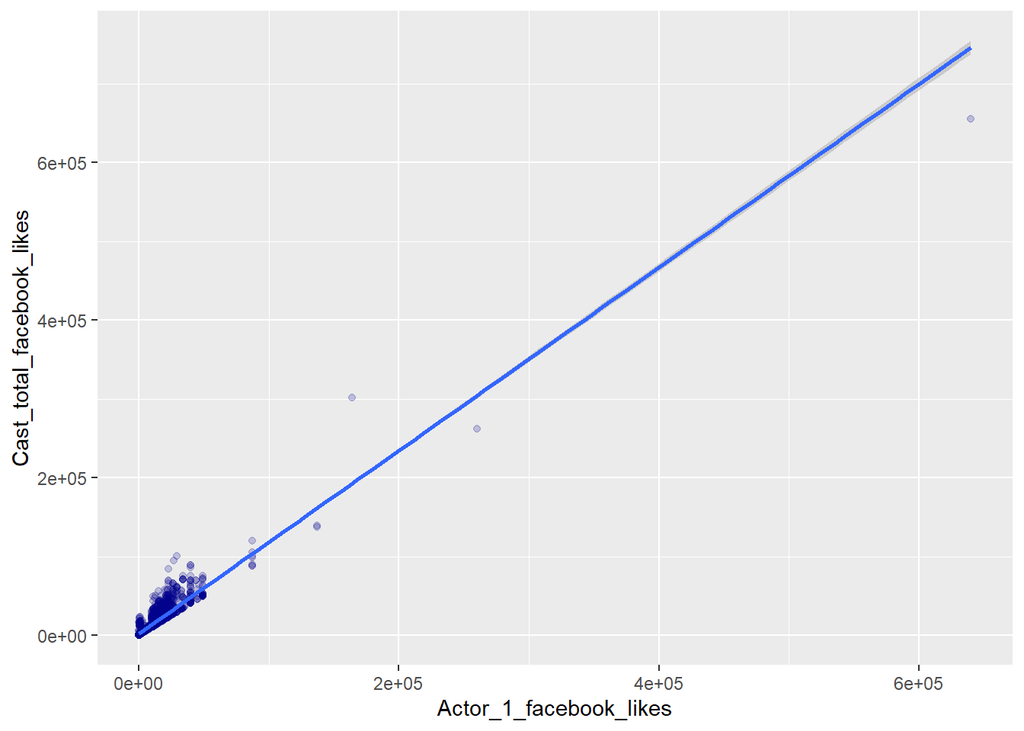

```r
ggplot(data = dat2, mapping = aes(y = Cast_total_facebook_likes, x = Actor_1_facebook_likes)) + geom_point(color = 'darkblue', alpha=1/5) +geom_smooth(method = "lm")
```

There is a very strong positive correlation between Actor_1_facebook_likes and Cast_total_facebook_likes probably because Actor_1_facebook_likes is a large part of Cast_total_facebook_likes so as Actor_1_facebook_likes increases, Cast_total_facebook_likes is expected to also increase as well.

Reviews has a strong positive correlation with Movie_facebook_likes with coefficient of 0.7

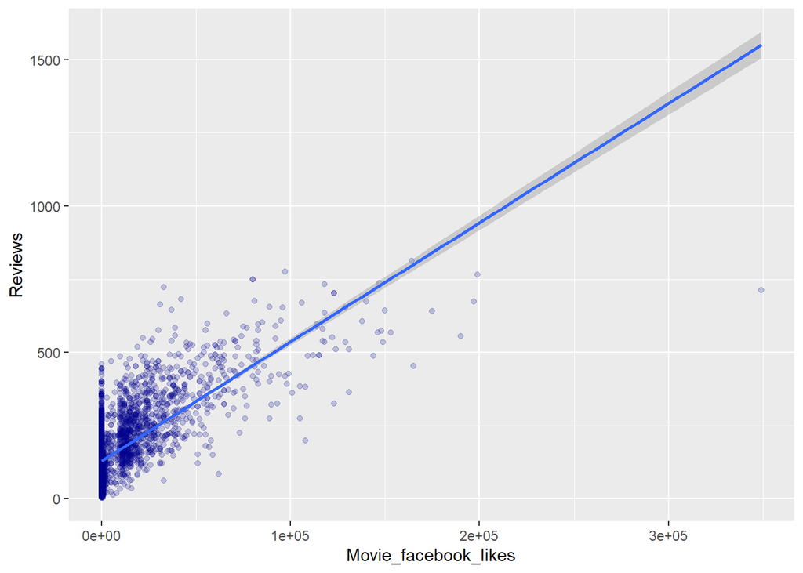

```r
ggplot(data = dat2, mapping = aes(x = Movie_facebook_likes, y = Reviews)) + geom_point(color = 'darkblue',alpha=1/5) +geom_smooth(method = "lm")
```

Reviews has a strong positive correlation with Movie_facebook_likes probably because if a movie has more reviews on IMDB, people will also look at that movie on fb and chances of that movie getting likes will also increase.

Reviews and Votes have positive correlation with coefficient 0.59

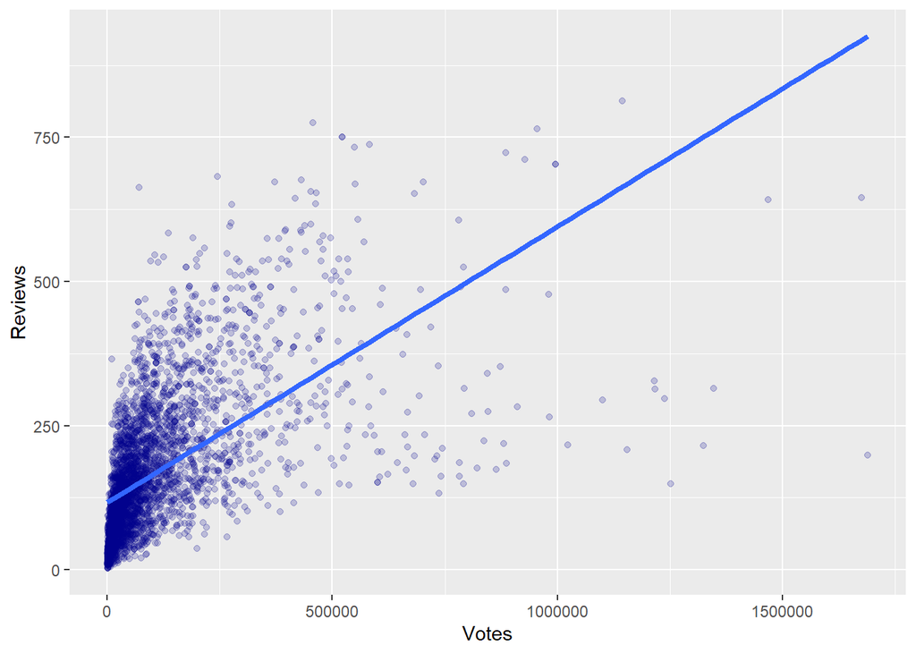

```r
ggplot(data = dat2, mapping = aes(x = Votes, y = Reviews)) + geom_point(color = 'darkblue', alpha = 1/5) +geom_smooth(se=FALSE,
              method = "lm",
              formula = y~poly(x,1),
              size = 1.5)
```

It is plausible to argue that the higher the votes are, the more reviews a movie can get because audience can have the tendency to select a movie to watch based on votes. After watching, they will review the movie.

Gross and Votes have positive correlation with coefficient being 0.62

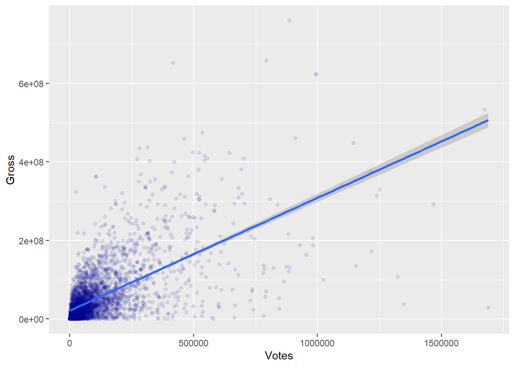

```r
ggplot(data = dat2, mapping = aes(x = Votes, y = Gross)) + geom_point(color = 'darkblue', alpha = 1/10) +geom_smooth(method = "lm")
```

It could be said that the more Votes a movies, the more people would want to watch the movie and hence the higher Gross income.

Actor_2_facebook_likes and Cast_total_facebook_likes have positive correlation with coefficient being 0.63

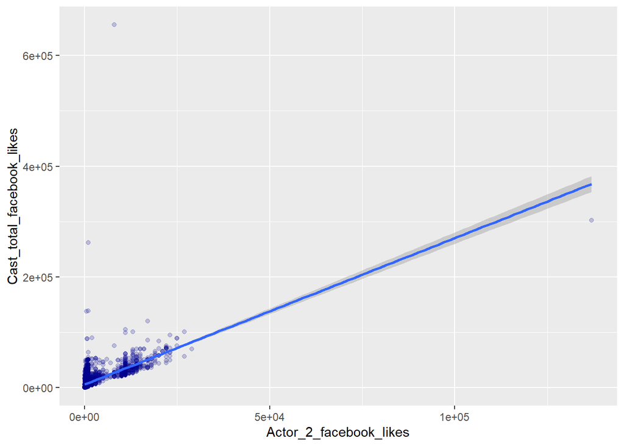

```r
ggplot(data = dat2, mapping = aes(x = Actor_2_facebook_likes, y = Cast_total_facebook_likes)) + geom_point(color = 'darkblue', alpha=1/5) +geom_smooth(method = "lm")
```

Actor_2_facebook_likes contributes to Cast_total_facebook_likes so the positive correlation here is self-explanatory. However, there are 2 outliners. The first one has high Actor_2_facebook_likes but low Cast_total_facebook_likes, this could be because the actor is popular but the rest of the cast is not. The second one has high Cast_total_facebook_likes but low Actor_2_facebook_likes, this could be because the 2nd actor is not popular but the rest of the cast are more fans’ favorites.

Budget has a very strong negative correlation with Profit with coefficient of -0.95

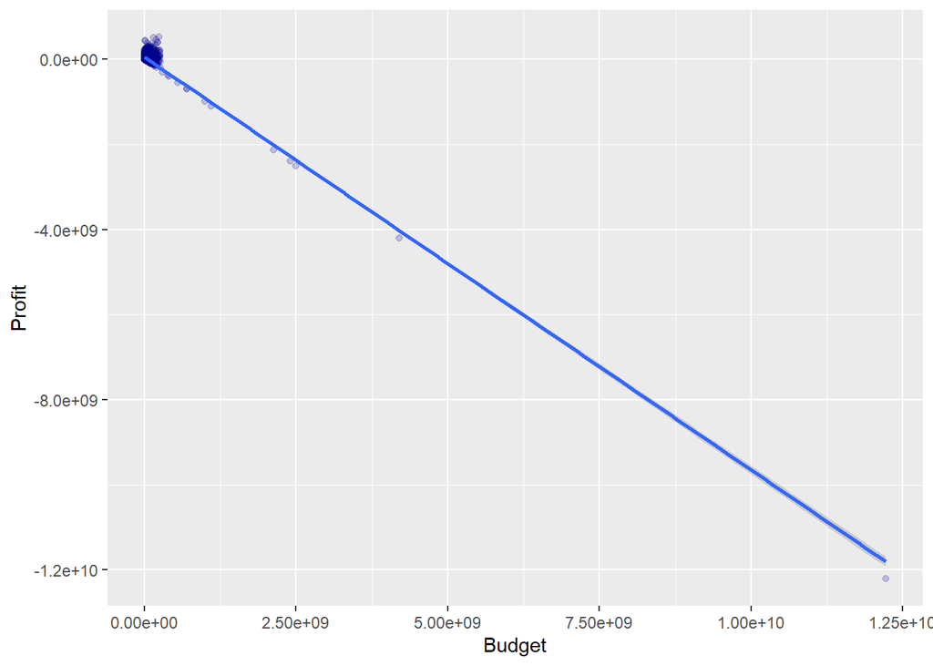

```r
ggplot(data = dat2, mapping = aes(x = Budget, y = Profit)) + geom_point(color = 'darkblue', alpha=1/5) +geom_smooth(method = "lm")
```

dat2 is used here instead of dat_profit because we want to include all movies so we can get the most accurate regression line for this correlation when coefficient is -0.95. If we use dat_profit, the regression line will be slightly upwards which doesn’t represent coefficient of -0.95.

Profit is Gross - Budget so mathematically, the higher the Budget, the lower the Profit and hence the negative correlation, hence the steep downwards slope.

#Weak correlations There are many weak correlations, some of the weakly correlated pairs are:

Duration and Profit only have coefficient of 0.01

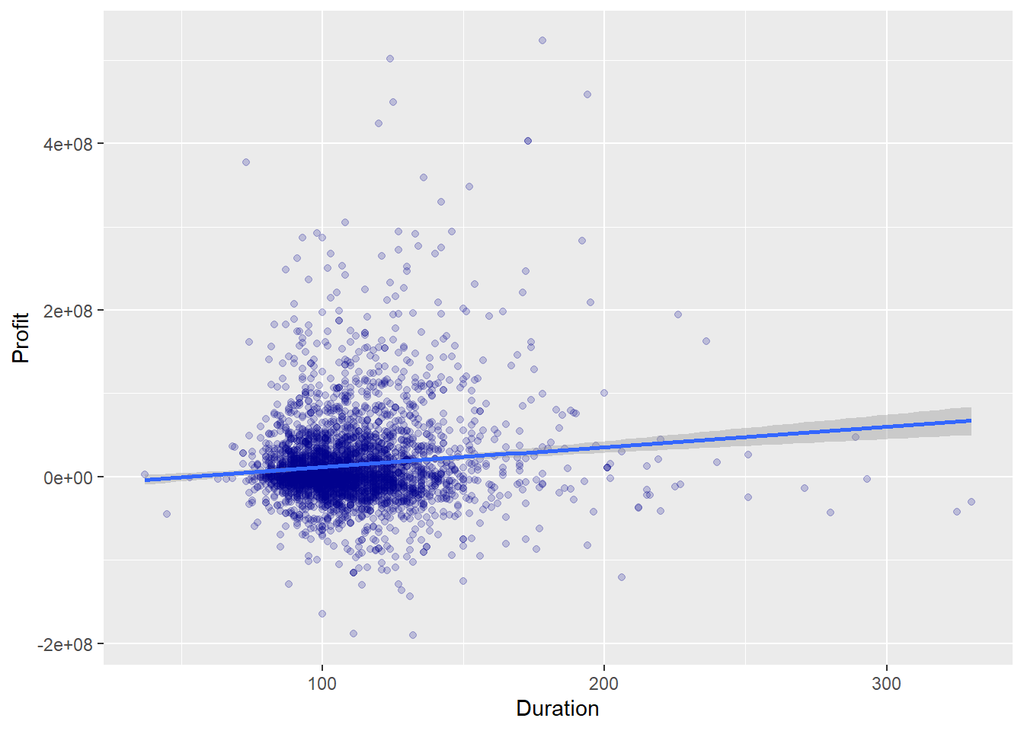

```r
ggplot(data = dat_profit, mapping = aes(x = Duration, y = Profit)) + geom_point(color = 'darkblue', alpha=1/5) +geom_smooth(method = "lm")
```

This is probably because the duration of the movie does not really determine how successful the movie is going to be. A long movie can have bad quality that leads to low profit.

Aspect_ratio and Profit only have coefficient of -0.01

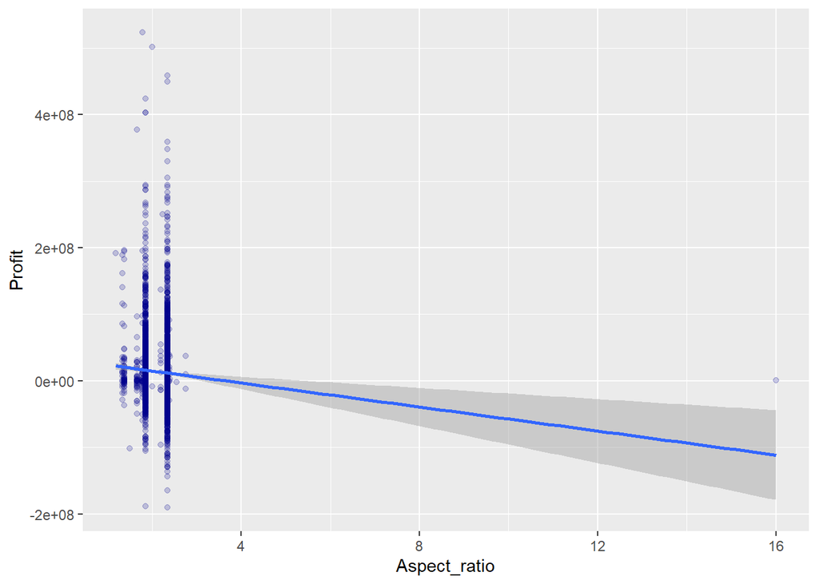

```r
ggplot(data = dat_profit, mapping = aes(x = Aspect_ratio, y = Profit)) + geom_point(color = 'darkblue', alpha=1/5) +geom_smooth(method = "lm")
```

In addition to the explanation about profit and aspect_ratio above, the aspect_ratio is probably isn’t one of the main factors that make the audience fall in love with a movie, it’s probably more about the content of the movie. Therefore, aspect_ratio doesn’t have a direct impact on a movie’s profit.

Facenumber_in_poster and Profit only have coefficient of 0.01

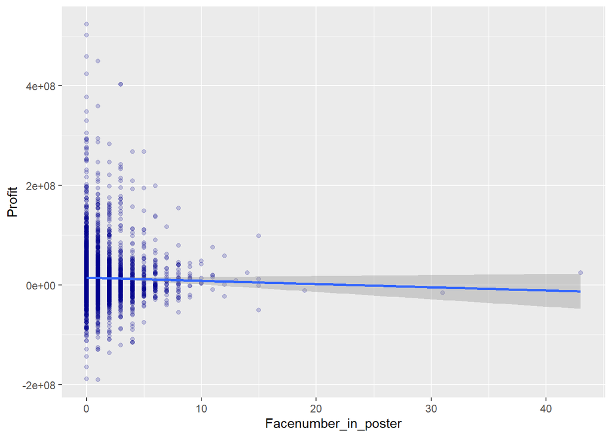

```r
ggplot(data = dat_profit, mapping = aes(x = Facenumber_in_poster, y = Profit)) + geom_point(color = 'darkblue',alpha=1/5) +geom_smooth(method = "lm")
```

There is probably isn’t a correlation here because the amount of faces appear in a poster doesn’t directly impact how successful a movie is. It is arguable that many bombshell movies have only 1 or 2 faces on the poster. Having too many faces on the poster could make tha poster forgetable and hence reduces the popularity of the movie which could also negatively impact a movie’s income.